# 2017-02-13

2017-03-26

## Today's topics

- Some observations about GitHub use and R Markdown
- Simulation as a tool for reproducible and transparent science
- Visualization tools in R

## Observations about GitHub use

- You're in charge of what goes where.
- Public repos are public, but no one knows what you're doing unless you alert them.
  - If you create a repo in your own account, add `rogilmore` or other collaborators to use the `@rogilmore` type at-mentions feature.
  - Files you create in `https://github.com/psu-psych-511-2017-spring` I can already comment on.

## Observations about GitHub use

- Pull requests are when you edit my code and want me to "pull"/adopt it.
  - If I'm a collaborator on the project with `write` privileges, I don't have to issue a pull request.

## Observations about R Markdown

- Ok to make multiple R Markdown files
- Make sure to add spaces where they belong: `##Header` vs. `## Header`
- Comments! Add them. This is your record of what you did.
- Don't forget you can hide things

## Be a risk-taker; be your own professor

- http://www.stat.cmu.edu/~cshalizi/rmarkdown
- http://stat545.com/bit006_github-browsability-wins.html

## Simulation as a tool for reproducible and transparent science

- Why simulate
- What to simulate
- How to simulate

## Why & what to simulate?

- Explore sample sizes, effect sizes, power
- Pre-plan/test, polish data-munging workflows
- Make hypotheses even more explicit
  - Simulation == Pregistration on steroids
  - 'X affects Y' -> 'Mean(X) > Mean(Y)'
  - or 'Mean(X) >= 2*Mean(Y)'
- Simulate data analysis in advance
- Plan data visualizations in advance
- Avoid avoidable errors
- Plan your work, work your plan
- Super easy to run analyses when your data come in

## How to simulate

- R functions
- R Markdown document(s)

## Super-simple example

- Hypothesis 1: Height (inches) is correlated with weight (lbs)

```r
# choose sample size
sample.n <- 200

# choose intercept and slope
beta0 <- 36   # inches
beta1 <- 0.33  # Rick's guess

# choose standard deviation for error
sigma <- 10 # Rick's guess
```

```r
# random weights between 80 lbs and 250 lbs (uniform sampling)
w <- runif(n = sample.n, min = 80, max = 250)

h.pred <- rep(x = beta0, n = sample.n) + beta1 * w
h <- h.pred + rnorm(n = sample.n, mean = 0, sd = sigma)
```

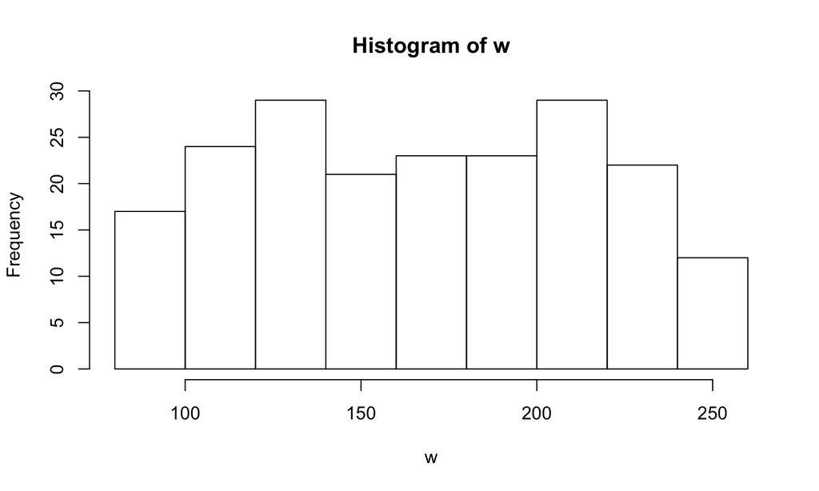

```r
library(ggplot2)
library(dplyr)

hist(w)
```

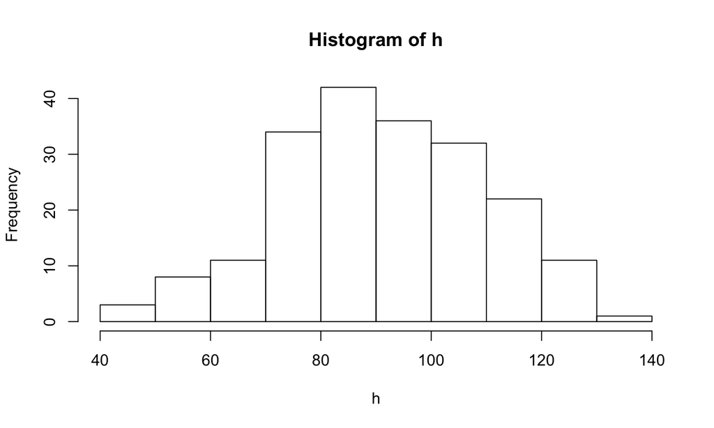

```r
hist(h)
```

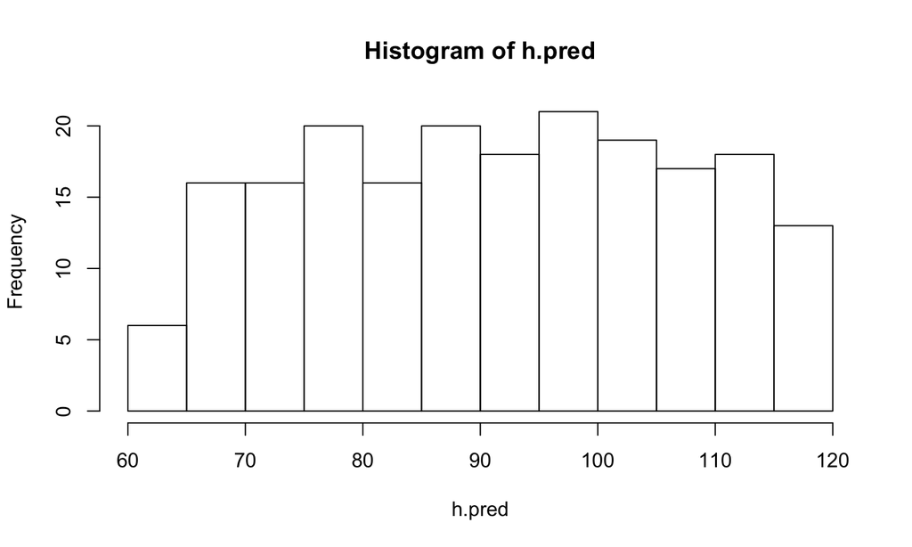

```r
hist(h.pred)
```

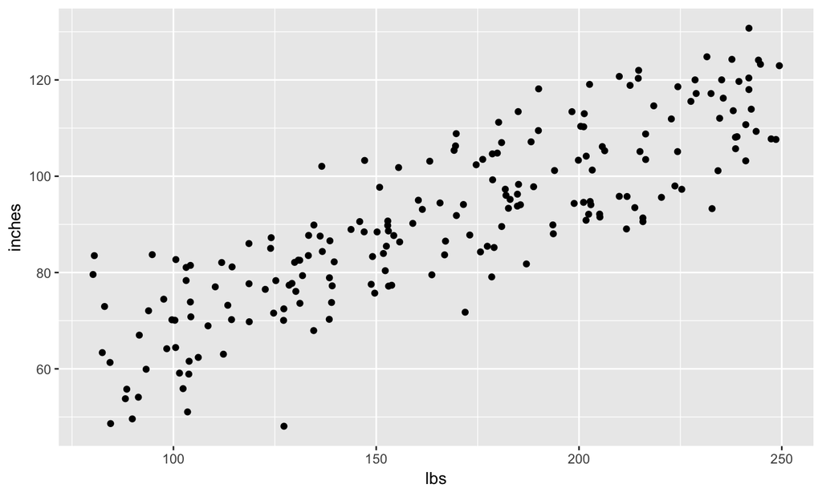

```r
# Put h and w into data frame for ggplot
height.weight <- data.frame(inches = h, lbs = w)

# Plot
scatter.1 <- ggplot(data = height.weight) +
  aes(x = lbs, y = inches) +
  geom_point()
scatter.1
```

## That's synthesis, now analysis

- Remember Hypothesis 1: Height (inches) is correlated with weight (lbs)?

```r
# Could use the raw data
# cor.test(x = w, y = h)
# Or, to use the values in the data frame, use with(...)

with(height.weight, cor.test(x = inches, y = lbs))
```

```
##
##  Pearson's product-moment correlation
##
## data:  inches and lbs
## t = 23.045, df = 198, p-value < 2.2e-16
## alternative hypothesis: true correlation is not equal to 0
## 95 percent confidence interval:
##  0.8107397 0.8871682
## sample estimates:
##      cor
## 0.853479
```

## Aside: extracting the statistics to make an interactive report

```r
# Save output as a variable
cor.test.inches.lbs <- with(height.weight, cor.test(x = inches, y = lbs))

# What sort of beast is this?
mode(cor.test.inches.lbs)
```

```
## [1] "list"
```

```r
# Aha, it's a list, this shows me all of the parts
unlist(cor.test.inches.lbs)
```

```
##                            statistic.t
##                     "23.0452612079269"
##                           parameter.df
##                                  "198"
##                                p.value
##                 "5.96940805986614e-58"
##                           estimate.cor
##                    "0.853478985128982"
##                 null.value.correlation
##                                    "0"
##                            alternative
##                            "two.sided"
##                                 method
## "Pearson's product-moment correlation"
##                              data.name
##                       "inches and lbs"
##                              conf.int1
##                     "0.81073972015561"
##                              conf.int2
##                    "0.887168163886266"
```

```r
# Looks like the t value is the first element
cor.test.inches.lbs[[1]]
```

```
##        t
## 23.04526
```

The Pearson's product-moment correlation correlation between height and weight is 0.853, \(t\)(198)=23.045, \(p\)=0.00000, with a 95\(\%\) confidence interval of [0.811, 0.887].

I did some formatting to make the numbers look pretty.

`sprintf("%.3f", my.var)` limits `my.var` to 3 decimal places; where `sprintf("%2.3f", my.var)` limits it to 2 digits to the left and 3 to the right.

## Now back to analysis with our synthetic data

```r
fit <- lm(formula = inches ~ lbs, data = height.weight)
summary(fit) # Use lm() command to fit formula
```

```
##
## Call:
## lm(formula = inches ~ lbs, data = height.weight)
##
## Residuals:
##      Min       1Q   Median       3Q      Max
## -30.0390  -7.5933   0.0997   6.9790  20.9250
##
## Coefficients:
##             Estimate Std. Error t value Pr(>|t|)
## (Intercept) 36.95021    2.44075   15.14   <2e-16 ***
## lbs          0.32355    0.01404   23.05   <2e-16 ***
## ---
## Signif. codes:  0 '***' 0.001 '**' 0.01 '*' 0.05 '.' 0.1 ' ' 1
##
## Residual standard error: 9.484 on 198 degrees of freedom
## Multiple R-squared:  0.7284, Adjusted R-squared:  0.7271
## F-statistic: 531.1 on 1 and 198 DF,  p-value: < 2.2e-16
```

```r
(ci <- confint(fit)) # confint() command fits confidence intervals
```

```
##                  2.5 %     97.5 %
## (Intercept) 32.1370046 41.7634057
## lbs          0.2958606  0.3512334
```

Surrounding `(ci <- confint(fit))` in parentheses saves variable ci and prints it out.

## How'd we do?

| Parameter | Actual | Low Estimate | High Estimate |
| --- | --- | --- | --- |
| \(\beta0\) | 36 | 32.1370046 | 41.7634057 |
| \(\beta1\) | 0.33 | 0.2958606 | 0.3512334 |

```
##
## Call:
## lm(formula = inches ~ lbs, data = height.weight)
##
## Residuals:
##      Min       1Q   Median       3Q      Max
## -30.9462  -5.7197   0.0986   7.6253  23.5393
##
## Coefficients:
##             Estimate Std. Error t value Pr(>|t|)
## (Intercept) 34.52642    2.55189   13.53   <2e-16 ***
## lbs          0.33962    0.01458   23.29   <2e-16 ***
## ---
## Signif. codes:  0 '***' 0.001 '**' 0.01 '*' 0.05 '.' 0.1 ' ' 1
##
## Residual standard error: 10.2 on 198 degrees of freedom
## Multiple R-squared:  0.7325, Adjusted R-squared:  0.7312
## F-statistic: 542.3 on 1 and 198 DF,  p-value: < 2.2e-16
```

```
##                 2.5 %     97.5 %
## (Intercept) 29.494059 39.5587843
## lbs          0.310861  0.3683823
```

| Parameter | Actual | Low Estimate | High Estimate |
| --- | --- | --- | --- |
| \(\beta0\) | 36 | 29.494059 | 39.5587843 |
| \(\beta1\) | 0.33 | 0.310861 | 0.3683823 |

## Simulation of fMRI data

- Critical review: Welvaert, M., & Rosseel, Y. (2014). A Review of fMRI Simulation Studies. PLOS ONE, 9(7), e101953. https://doi.org/10.1371/journal.pone.0101953.
- Welvaert, M., Durnez, J., Moerkerke, B., Berdoolaege, G. & Rosseel, Y. (2011). neuRosim: An R Package for Generating fMRI Data. Journal of Statistical Software, 44(10). Retrieved from https://www.jstatsoft.org/article/view/v044i10
- AFNI's *AlphaSim*, https://afni.nimh.nih.gov/pub/dist/doc/program_help/AlphaSim.html

## Visualization in R

## Plot first, analyze last

- Why?
- [Mike Meyer](https://www.linkedin.com/in/mike-meyer-0056578a) told me so
- Less biased
- Easier to be transparent and reproducible
- Want/need to plot eventually anyway
- If a picture's worth a thousand words…
- How?

## How

- Base graphics
  - `plot(x,y)` `hist(x)`, `coplot()`
- `ggplot2`
  - Grammar of graphics

## Base graphics

- Try it, maybe you'll like it
- `plot()` takes many types of input
- So does `summary()`
- A little harder to customize

## Data visualization with ggplot2

Wickham, H. & Grolemund, G. (2017). *R for Data Science*. O'Reilly. http://r4ds.had.co.nz/

## Let's just walk through the data visualiation chapter

http://r4ds.had.co.nz/data-visualisation.html

## Other ggplot2 resources

- Wickham, H. (2010). *ggplot2: Elegant Graphics for Data Analysis (Use R!)* http://ggplot2.org/book/
- ggplot2 2.1.0 documentation: http://docs.ggplot2.org/current/